# Ch02 Process Analysis Basic

2020-04-23T23:20:39+09:00

## I. 개요

지난시간에 `patients`에 관한 데이터를 통해서 프로세스 분석에 대한 일반적인 개념을 접했다.

이번 포스트에서는 `bupaR`에 대한 이론적인 내용과 함께 간단하게 실습을 진행하도록 한다.

지난시간과 마찬가지로 먼저 데이터를 획득하는 것에서부터 출발한다.

```r
library(bupaR)
library(eventdataR)
patients <- patients
dim(patients)
```

```
## [1] 5442    7
```

5442행과 7개의 열이 확인되었다.

```r
class(patients)
```

```
## [1] "eventlog"   "tbl_df"     "tbl"        "data.frame"
```

그리고, 데이터는 `eventlog`, `tbl_df`, `data.frame`으로 구성된 것을 확인할 수 있다. 기존에 R을 학습한 사람들은 `tbl & data.frame`에 대해서 한두번쯤 들었을 거라 생각한다. 그러나 `eventlog`는 생소한 객체임을 알 수 있다.

조금더 구체적으로 확인하기 위해 데이터를 살펴보자.

```r
library(dplyr)
glimpse(patients)
```

```
## Rows: 5,442
## Columns: 7
## $ handling          <fct> Registration, Registration, Registration, Registrat…
## $ patient           <chr> "1", "2", "3", "4", "5", "6", "7", "8", "9", "10", …
## $ employee          <fct> r1, r1, r1, r1, r1, r1, r1, r1, r1, r1, r1, r1, r1,…
## $ handling_id       <chr> "1", "2", "3", "4", "5", "6", "7", "8", "9", "10", …
## $ registration_type <fct> start, start, start, start, start, start, start, st…
## $ time              <dttm> 2017-01-02 11:41:53, 2017-01-02 11:41:53, 2017-01-…
## $ .order            <int> 1, 2, 3, 4, 5, 6, 7, 8, 9, 10, 11, 12, 13, 14, 15, …
```

```r
summary(patients)
```

```
## Number of events:  5442
## Number of cases:  500
## Number of traces:  7
## Number of distinct activities:  7
## Average trace length:  10.884
##
## Start eventlog:  2017-01-02 11:41:53
## End eventlog:  2018-05-05 07:16:02
```

```
##                   handling      patient          employee  handling_id
##  Blood test           : 474   Length:5442        r1:1000   Length:5442
##  Check-out            : 984   Class :character   r2:1000   Class :character
##  Discuss Results      : 990   Mode  :character   r3: 474   Mode  :character
##  MRI SCAN             : 472                      r4: 472
##  Registration         :1000                      r5: 522
##  Triage and Assessment:1000                      r6: 990
##  X-Ray                : 522                      r7: 984
##  registration_type      time                         .order
##  complete:2721     Min.   :2017-01-02 11:41:53   Min.   :   1
##  start   :2721     1st Qu.:2017-05-06 17:15:18   1st Qu.:1361
##                    Median :2017-09-08 04:16:50   Median :2722
##                    Mean   :2017-09-02 20:52:34   Mean   :2722
##                    3rd Qu.:2017-12-22 15:44:11   3rd Qu.:4082
##                    Max.   :2018-05-05 07:16:02   Max.   :5442
##
```

`patterns`라는 데이터셋은 병원 응급실에서 발생한 데이터와 연관이 있고, `model level`, `instance level`, 그리고 `event level`로 구성되어 있음을 알 수 있다.

## II. EDA - 기초통계량

### (1) 환자에 대한 기록

- 우선 5442개의 데이터에서 실제 환자의 수는 몇명일까? `summary`에서 확인이 가능했지만, `n_cases()` 함수를 활용하면 쉽게 구할 수 있다.

```r
n_cases(patients)
```

```
## [1] 500
```

- 이번에는 첫번째 환자의 여정을 살펴보도록 한다.

```r
slice(patients, 1)
```

```
## Log of 12 events consisting of:
## 1 trace
## 1 case
## 6 instances of 6 activities
## 6 resources
## Events occurred from 2017-01-02 11:41:53 until 2017-01-09 19:45:45
##
## Variables were mapped as follows:
## Case identifier:     patient
## Activity identifier:     handling
## Resource identifier:     employee
## Activity instance identifier:    handling_id
## Timestamp:           time
## Lifecycle transition:        registration_type
##
## # A tibble: 12 x 7
##    handling patient employee handling_id registration_ty… time
##    <fct>    <chr>   <fct>    <chr>       <fct>            <dttm>
##  1 Registr… 1       r1       1           start            2017-01-02 11:41:53
##  2 Triage … 1       r2       501         start            2017-01-02 12:40:20
##  3 Blood t… 1       r3       1001        start            2017-01-05 08:59:04
##  4 MRI SCAN 1       r4       1238        start            2017-01-05 21:37:12
##  5 Discuss… 1       r6       1735        start            2017-01-07 07:57:49
##  6 Check-o… 1       r7       2230        start            2017-01-09 17:09:43
##  7 Registr… 1       r1       1           complete         2017-01-02 12:40:20
##  8 Triage … 1       r2       501         complete         2017-01-02 22:32:25
##  9 Blood t… 1       r3       1001        complete         2017-01-05 14:34:27
## 10 MRI SCAN 1       r4       1238        complete         2017-01-06 01:54:23
## 11 Discuss… 1       r6       1735        complete         2017-01-07 10:18:08
## 12 Check-o… 1       r7       2230        complete         2017-01-09 19:45:45
## # … with 1 more variable: .order <int>
```

`slice(patients, 1)` 함수를 적용하니, 첫번째 case에 대한 모든 기록이 다 나오는 것을 확인할 수 있다. 상상력을 발휘해서, 환자의 보호자를 떠오르면, `handling`의 의미(병원 등록부터 수납까지)를 쉽게 파악할 수 있다.

### (2) 병원내 활동 현황

두번째로 확인할 수 있는 것은 500명 환자가 활동한 `activity`에 대한 기초통계량이다.

```r
n_activities(patients)
```

```
## [1] 7
```

우선 총 7개의 활동 영역을 확인 할 수 있다. 그러면 각 활동의 이름은 어떻게 될까?

```r
activity_labels(patients)
```

```
## [1] Registration          Triage and Assessment Blood test
## [4] MRI SCAN              X-Ray                 Discuss Results
## [7] Check-out
## 7 Levels: Blood test Check-out Discuss Results MRI SCAN ... X-Ray
```

우선 범주형 벡터로 확인되었고, 병원과 관련있는 용어로 구성되어 있음을 확인했다. 그런데, `Triage and Assessment`가 있다. 이 용어는 응급환자 분류와 평가에 대한 항목[^1]인데, `patients` 데이터가 응급환자와 관련된 데이터임을 확인할 수 있다.

그러면, 각 활동의 빈도수는 어떻게 될까? 환자 500명이 각각의 활동을 할 것인데, 분명히 프로세스에 따라 그 빈도수가 차이가 날 것임을 예상할 수 있다.

```r
activities(patients)
```

```
## # A tibble: 7 x 3
##   handling              absolute_frequency relative_frequency
##   <fct>                              <int>              <dbl>
## 1 Registration                         500             0.184
## 2 Triage and Assessment                500             0.184
## 3 Discuss Results                      495             0.182
## 4 Check-out                            492             0.181
## 5 X-Ray                                261             0.0959
## 6 Blood test                           237             0.0871
## 7 MRI SCAN                             236             0.0867
```

당연한 말이지만, 환자가 병원에 오면 무조건 밟아야 하는 기본 절차인 `Registration` & `Triage and Assessment` (등록과 응급환자 분류와 평가)는 기본적인 절차이기 때문에 500명, 즉 환자수와 일치하지만, 나머지는 상이한 것을 볼 수 있다.

### (3) 프로세스 경로와 관련된 현황

환자가 등록을 하면, 피검사를 할지, X-Ray를 할지 등으로 분류가 될 것이다. 이러한 경로가 몇개 나왔는지 확인을 해본다.

```r
traces(patients)
```

```
## # A tibble: 7 x 3
##   trace                                      absolute_frequen… relative_frequen…
##   <chr>                                                  <int>             <dbl>
## 1 Registration,Triage and Assessment,X-Ray,…               258             0.516
## 2 Registration,Triage and Assessment,Blood …               234             0.468
## 3 Registration,Triage and Assessment,Blood …                 2             0.004
## 4 Registration,Triage and Assessment,X-Ray                   2             0.004
## 5 Registration,Triage and Assessment                         2             0.004
## 6 Registration,Triage and Assessment,X-Ray,…                 1             0.002
## 7 Registration,Triage and Assessment,Blood …                 1             0.002
```

총 7개가 나오는 것으로 확인이 된다.

위 테이블을 시각화를 해본다. 이미 이러한 시각화를 할 수 있도록 `processmapR` 패키지가 있어서 매우 쉽게 시각화를 할 수 있다.

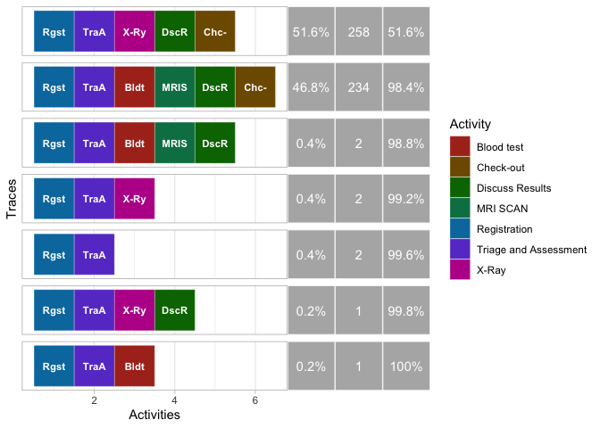

```r
library(processmapR)
trace_explorer(patients, coverage=1)
```

그러면 지난 포스트에서 잠깐 봤던 이미지가 다시 출력되는 것을 확인할 수 있다.

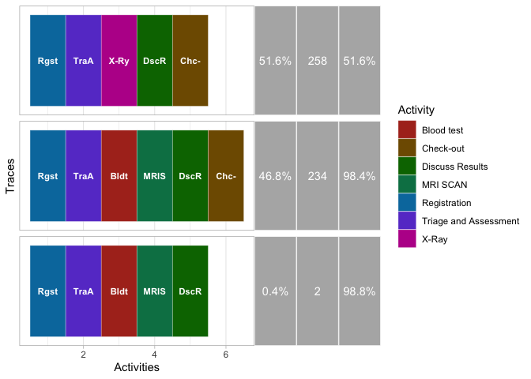

```r
trace_explorer(patients, coverage = 0.986)
```

### (4) 프로세스 지도

이번에는 위 데이터의 현황에 대해 전체적인 프로세스가 어떻게 진행되는지 확인해본다.

```r
library(processmapR)
process_map(patients)
```

[interactive chart not shown]

전체적으로 경로 현황에 대해 보다 시각적으로 나타난 것으로 확인이 되었다. 위 시각화에 대한 분석은 각자 맡기도록 한다.

다만, 중요한 것은 이렇게 시각화를 통하여 응급환자의 이동 경로를 매우 쉽고 빠르게 확인할 수 있다는 점이다.

## III. 결론

이 부분이 만약 다른 업종과 연계되어 접근이 되면 어떻게 될까? 아니, 다른 업종도 위와 같은 데이터를 구성해서 활용할 수 있을까?

다음 시간에는 event data를 실제로 생성하는 작업을 해보도록 해서 응용하도록 한다.

## VI. Reference

R on notast. “Process Mining (Part 1/3): Introduction to BupaR Package.” R, 7 Mar. 2019, www.r-bloggers.com/process-mining-part-1-3-introduction-to-bupar-package/.

Aalst, W.m.p. Van Der, and A.j.m.m. Weijters. “Process Mining: a Research Agenda.” Computers in Industry, vol. 53, no. 3, 2004, pp. 231–244., doi:10.1016/j.compind.2003.10.001.

[^1]: 아이라. (2017). KTAS 한국형 외상. 응급환자 분류와 평가(Triage and Assessment). Retrieved from https://m.blog.naver.com/tinaarena/221070718090